# Practical

Katherine Filpo

4/6/2020

*Word Equation*

Biomass ~ light + water treatment

*Hypotheses*

H<sub>01</sub> The water treatment will have no effect on the biomass of the sunflowers.

H<sub>A1</sub> The water treatment will have an effect on the biomass of the sunflowers.

H<sub>02</sub> The amount of sunlight will have no effect on the biomass of the sunflowers.

H<sub>A2</sub> The amount of sunlight will have an effect on the biomass of the sunflowers.

H<sub>03</sub> The light and water treatment will not have an effect on the biomass of the sunflowers.

H<sub>A3</sub> The light and water treatment will not have an effect on the biomass of the sunflowers.

### Analysis of Water Treatment

```r
model_1 <-aov(SUNFLOWER$BIOMASS ~ SUNFLOWER$WATER)
summary(model_1)
```

```
##                 Df Sum Sq Mean Sq F value   Pr(>F)
## SUNFLOWER$WATER  1 103426  103426   21.56 9.39e-05 ***
## Residuals       25 119922    4797
## ---
## Signif. codes:  0 '***' 0.001 '**' 0.01 '*' 0.05 '.' 0.1 ' ' 1
```

### Analysis of Light Treatment

```r
model_2 <-aov(SUNFLOWER$BIOMASS ~ SUNFLOWER$DENSITY)
summary(model_2)
```

```
##                   Df Sum Sq Mean Sq F value Pr(>F)
## SUNFLOWER$DENSITY  1  31154   31154   4.052  0.055 .
## Residuals         25 192194    7688
## ---
## Signif. codes:  0 '***' 0.001 '**' 0.01 '*' 0.05 '.' 0.1 ' ' 1
```

### Analysis of Both Water and Light Treatment

```r
model_3 <-aov(SUNFLOWER$BIOMASS ~ (SUNFLOWER$DENSITY+SUNFLOWER$WATER))
summary(model_3)
```

```
##                   Df Sum Sq Mean Sq F value   Pr(>F)
## SUNFLOWER$DENSITY  1  31154   31154   8.423  0.00782 **
## SUNFLOWER$WATER    1 103426  103426  27.963 2.01e-05 ***
## Residuals         24  88768    3699
## ---
## Signif. codes:  0 '***' 0.001 '**' 0.01 '*' 0.05 '.' 0.1 ' ' 1
```

## Figures

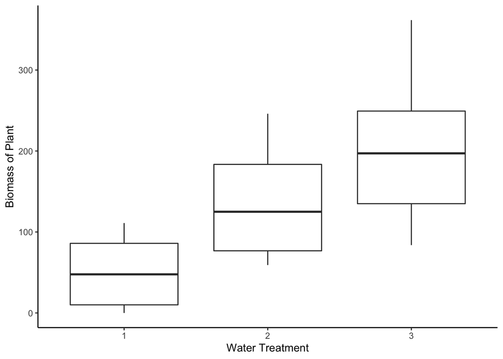

*Figure 1.* The biomass of plants are higher when the water treatment is similarly greater, supporting the H<sub>A1</sub>, **F**(1,25)= 21.56.

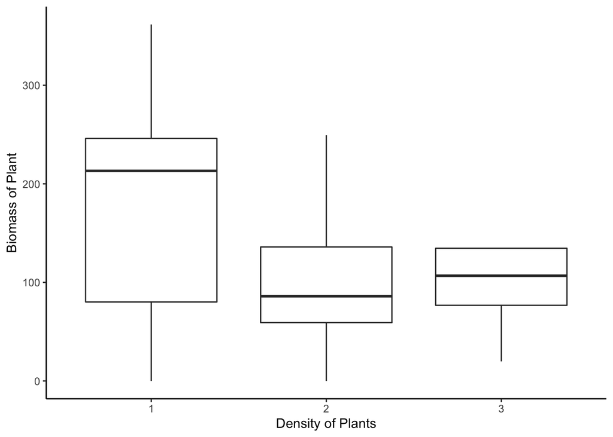

*Figure 2.* The biomass of the plants are higher when the density of the plants is lower but the relationship seems to be weak and the H<sub>02</sub> must be accepted, **F**(1,25)= 4.052.

## Conclusion

The best way to get the most biomass of the sunflower seeds is to have a higher water treatment and have less density of plants **F**(1,24)= 8.423.